# Programming with R Test #1

Lemke, Michael

### Test Items

Read each question carefully and address each element. Do not print contents of vectors or data frames unless requested.

##### (1) (4 points) This problem deals with vector manipulations.

(1)(a) Create a vector that contains the following, in this order, and print the contents. Do not round off any values unless requested. * A sequence of integers from 0 to 6, inclusive. * Two repetitions of the vector c(2, -5.1, -23). * The sum of 7/42 and 3

```r
#Bullet One
#Create a vector which contains sequence of integers from 0 to 6, inclusive of 0 and 6.
first_bullet  <- c(0:6)

#Bullet Two
#Create a vector which contains two repetitions of 2, -5.1, -23. Note the use of a repeater.
second_bullet <- rep(c(2, -5.1, -23), times = 2)

#Bullet Three
#Create a vector which contains the sum of 7/42 and 3 without rounding.
thrid_bullet  <- c(7/42+3)

#Getting to the point, concatenate the bullet vectors to create "a vector".
vector_1a <- c(first_bullet, second_bullet, thrid_bullet)

#Print the resulting vector
print(vector_1a)
```

```
##  [1]   0.000000   1.000000   2.000000   3.000000   4.000000   5.000000
##  [7]   6.000000   2.000000  -5.100000 -23.000000   2.000000  -5.100000
## [13] -23.000000   3.166667
```

(1)(b) Determine the length of the vector created in (1)(a) and denote as L. Print L. Generate a sequence starting with 1 and ending with L and add to the vector from (1)(a). This is vector addition, not vector combination. Print the contents. Do not round off any values.

```r
#Create variable L and store the length of the vector.
L <- length(vector_1a)

#Print L
print(L)
```

```
## [1] 14
```

```r
#Generate a sequence starting with 1 and ending with L.
sequence_1_to_L <- 1:L

#Add to the vector from (1)(a).
vector_1b <- vector_1a + sequence_1_to_L

#Print the new vector.
print(vector_1b)
```

```
##  [1]   1.00000   3.00000   5.00000   7.00000   9.00000  11.00000  13.00000
##  [8]  10.00000   3.90000 -13.00000  13.00000   6.90000 -10.00000  17.16667
```

(1)(c) Extract the first and last elements of the vector you have created in (1)(b) to form another vector using the extracted elements. Form a third vector from the elements not extracted. Print these vectors.

```r
#Extract the first and last elements of the vector_1b.
vector_1c_first_last <- vector_1b[c(1,L)]

#Extract all elements that are not first or last elements of the vector_1b.
vector_1c_inner <- vector_1b[-c(1,L)]

#Print these vectors.
print(vector_1c_first_last)
```

```
## [1]  1.00000 17.16667
```

```r
print(vector_1c_inner)
```

```
##  [1]   3.0   5.0   7.0   9.0  11.0  13.0  10.0   3.9 -13.0  13.0   6.9
## [12] -10.0
```

(1)(d) Use the vectors from (c) to reconstruct the vector in (b). Print this vector. Sum the elements and round to two decimal places.

```r
#Reconstruct the vector from 1c.
#I feel like we are in the military and I am filling in the whole that I just dug. :)
vector_1d <- c(vector_1c_first_last[1], vector_1c_inner ,vector_1c_first_last[2])

#Printing deconstructed-reconstructed vector! LOL.
vector_1d
```

```
##  [1]   1.00000   3.00000   5.00000   7.00000   9.00000  11.00000  13.00000
##  [8]  10.00000   3.90000 -13.00000  13.00000   6.90000 -10.00000  17.16667
```

```r
#Sum of all elements in vector 1d.
vector_1d_sum <- sum(vector_1d)

#Round to two decimal places.
vector_1d_sum_rounded <- round(vector_1d_sum, 2)

#Print our rounded sum of elements in the vector.
print(vector_1d_sum_rounded)
```

```
## [1] 76.97
```

##### (2) (5 points) The expression y = sin(x) - cos(x) is a trigonometric function.

(2)(a) Using the trigonometric function above, write a function as defined by R in the proper format that accepts values for x and returns a value for y.

```r
#Define an R function for the equation given above.
rFunction <- function(x){
  y <- sin(x) - cos(x)
  return(y)
  }
```

Finding the two desired values can be accomplished in as few as two lines of code. Do not use packages or programs you may find on the internet or elsewhere. Do not print the elements of the vectors x and y. Use coding methods shown in the *Quick Start Guide for R*.

```r
#Create a vector of 4001 equally-spaced values from -2 to 2, inclusive.
vector_x <- seq(-2, 2, length.out = 4001)

#Create a vector of f(vector_x)
vector_y <- lapply(vector_x, FUN = rFunction)

#Print the value of x with the minimum value of y after rounding it to 3 decimal places.
print(round(vector_x[which.min(vector_y)], 3))
```

```
## [1] -0.785
```

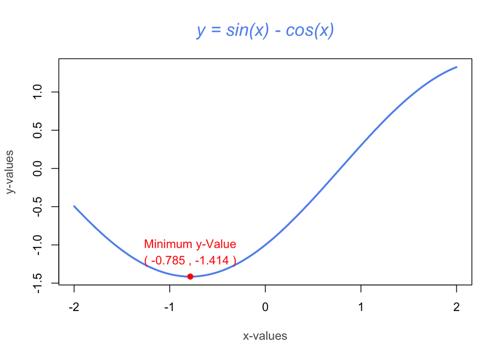

```r
#Plot y = sin(x) - cos(x).
plot(vector_x, vector_y, pch=20, xlab = "x-values", ylab = "y-values", col.lab="gray35", cex = .25 , col = "cornflowerblue", main = list("y = sin(x) - cos(x)", cex = 1.5,
                  col = "cornflowerblue", font = 3))

#Plot minimum point.
points(vector_x[which.min(vector_y)], vector_y[which.min(vector_y)], col = "red", cex = 1, pch=19)

#Add text features.
text(vector_x[which.min(vector_y)], -1, col = "red", cex = 1, "Minimum y-Value")
text(vector_x[which.min(vector_y)], -1.21, col = "red", cex = 1, paste("(",round(vector_x[which.min(vector_y)],3),",",round(as.numeric(vector_y[which.min(vector_y)]),3),")"))
```

##### (3) (8 points) Use the “trees” dataset for the following items. This dataset has three variables (Girth, Height, Volume) on 31 trees.

(3)(a) Use *data(trees)* to load the file. Check the structure with *str()*. Use *apply()* to return the median values for the three variables in “trees.” Using R and logicals, print the row number and the three measurements: Girth, Height and Volume, of the tree with Volume equal to median Volume.

```r
#Load data from tress.
data(trees)

#Check the structure.
str(trees)
```

```
## 'data.frame':    31 obs. of  3 variables:
##  $ Girth : num  8.3 8.6 8.8 10.5 10.7 10.8 11 11 11.1 11.2 ...
##  $ Height: num  70 65 63 72 81 83 66 75 80 75 ...
##  $ Volume: num  10.3 10.3 10.2 16.4 18.8 19.7 15.6 18.2 22.6 19.9 ...
```

```r
#Return median values for three variables in trees.
apply(trees, 2, FUN = median)
```

```
##  Girth Height Volume
##   12.9   76.0   24.2
```

```r
#Find index value where volume equal to median volume.
tree_index <- which(trees$Volume == median(trees$Volume))

#Print Girth, Height and Volume, of the tree with Volume equal to median Volume.
print(trees[tree_index,])
```

```
##    Girth Height Volume
## 11  11.3     79   24.2
```

(3)(b) Girth is defined as the diameter of a tree taken at 4 feet 6 inches from the ground. Convert each diameter to a radius, r. Calculate the cross-sectional area of each tree using pi times the squared radius. Sort Radius ascending and print. Present the stem-and-leaf plot of the radius, and a histogram of the radius in color.

```r
#Calculate the radius values for trees given the girth and store as a new variable in trees.
trees$Radius <- as.double(lapply(trees$Girth, function(x) x/2))

#Print the radius sorted in ascending order.
print(sort(trees$Radius, decreasing = FALSE))
```

```
##  [1]  4.15  4.30  4.40  5.25  5.35  5.40  5.50  5.50  5.55  5.60  5.65
## [12]  5.70  5.70  5.85  6.00  6.45  6.45  6.65  6.85  6.90  7.00  7.10
## [23]  7.25  8.00  8.15  8.65  8.75  8.95  9.00  9.00 10.30
```

```r
#Present the stem-and-leaf plot of trees$Radius.
stem(trees$Radius)
```

```
##
##   The decimal point is at the |
##
##    4 | 234
##    5 | 34455667779
##    6 | 055799
##    7 | 013
##    8 | 0278
##    9 | 000
##   10 | 3
```

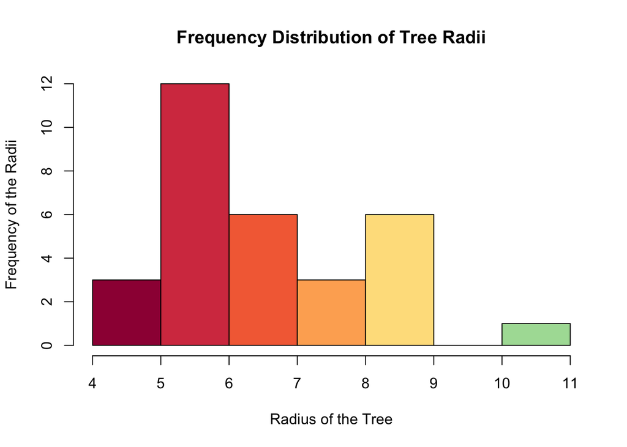

```r
#Define a function that computes cross-sectional area.
cs_area <- function(r){
  area <- pi*r^2
  return(area)
  }

#Calculate the cross-sectional area of each tree using our new radius variable for each tree.
trees$Area <- as.double(lapply(trees$Radius, function(x) cs_area(x)))

#Present a histogram of the radius in color
require("RColorBrewer")
hist(trees$Radius, main = "Frequency Distribution of Tree Radii", ylab = "Frequency of the Radii", xlab = "Radius of the Tree", col = c(brewer.pal(10, "Spectral")))
```

(3)(c) Use *par(mfrow = c(1, 4))* and present colored boxplots of the radii and areas calculated in (b) along with Height and Volume. Label each accordingly.

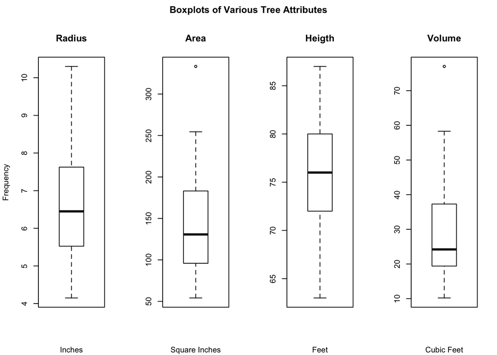

```r
#Configure multi-plot.
par(mfrow = c(1, 4), oma=c(0,0,2,0))

#Plot radii and area boxplots along with height and volume.
boxplot(trees$Radius, main = "Radius", ylab = "Frequency", sub = "Inches")
boxplot(trees$Area, main = "Area", sub = "Square Inches")
boxplot(trees$Height, main = "Heigth", sub = "Feet")
boxplot(trees$Volume, main = "Volume", sub = "Cubic Feet")
title("Boxplots of Various Tree Attributes", outer = TRUE)
```

(3)(d) Demonstrate that the outlier revealed in the boxplot of Volume is not an extreme outlier. It is possible to do this with one line of code using *boxplot.stats* or logicals.

```r
#Show that the volume of 77 is not an extreme outlier.
#Let's assume there are no extreme outliers and check to see if we are right.
length(boxplot.stats(trees$Volume, coef = 3)$out) == 0
```

```
## [1] TRUE
```

##### (4) (2 points) Use matrix operations shown in the “Quick Start Guide” to solve the following system of linear equations. Display the R script and the numerical solutions for x, y and z. Use matrix operations with your solution to reproduce the values 1, 1, 3 as a means of checking if your solution is correct. This last demonstration can be accomplished with matrix multiplication in one line of code. Print your result.

**x - y + z = 1**

**x + y + z = 1**

**x + y - z = 3**

```r
#Setup our system of equations.
system_values <- c(1,1,3)
system_coefficients <- matrix(c(1, -1, 1, 1, 1, 1, 1, 1, -1), nr = 3, byrow = T)

#Solve the system of equations.
solve(system_coefficients, system_values)
```

```
## [1]  2  0 -1
```

```r
#Verify the solution
system_coefficients%*%(solve(system_coefficients, system_values))
```

```
##      [,1]
## [1,]    1
## [2,]    1
## [3,]    3
```

##### (5) (6 points) The Cauchy distribution is an example of a “heavy-tailed” distribution in that it will have (more) outliers in both tails. This problem involves comparing it with a normal distribution which typically has very few outliers.

5(a) Use *set.seed(124)* and *rcauchy()* with n = 100, location = 0 and scale = 0.1 to generate a random sample designated as y. Generate a second random sample designated as x with *set.seed(127)* and *rnorm()* using n = 100, mean = 0 and sd = 0.15.

Generate a new object using *cbind(x, y)*. Do not print this object. Use *apply()* with this object to compute the inter-quartile range or IQR for each column: x and y. Round the results to four decimal places and present. (The point of this exercise is to demonstrate the similarity of the IQR values.)

For information about rcauchy(), use help in R (?rcauchy). **Do not print x and y.**

```r
#Set seed and generate random sample with Cauchy distribution designated as y.
set.seed(124)
y <- rcauchy(n = 100, location = 0, scale = 0.1)

#Set new seed and generate second random sample with normal distribution designated as x.
set.seed(127)
x <- rnorm(n = 100, mean = 0, sd = 0.15)

#Combine Vectors.
cauchy_normal <-cbind(x,y)

#Compute IQR of each random sample.
cauchy_normal_IQR <-apply(cauchy_normal, 2, FUN = IQR)

#Print the IQR of each random sample.
print(round(cauchy_normal_IQR, 4))
```

```
##      x      y
## 0.2041 0.2141
```

(5)(b) This item will illustrate the difference between a heavy-tailed distribution and one which does not have heavy tails. Use *par(mfrow = c(2, 2))* to generate a display with four diagrams. On the first row, present two histograms in color, one for x and the second for y. Set *xlim = c(-7, 7)* for the Cauchy results, and *xlim = c(-0.45, 0.45)* for the Normal results. Do not specify ylim for the histograms. On the second, show vertical boxplots for x and y. Use the xlim interval values respectively for the ylim of the boxplots.

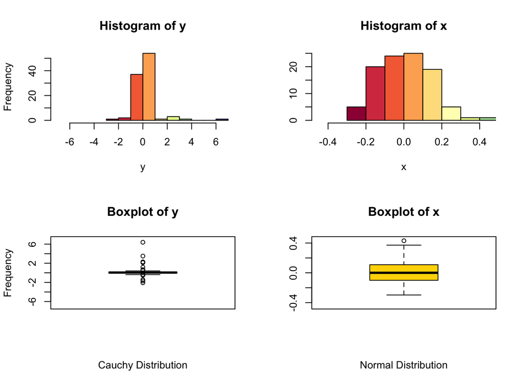

```r
#Configure multi-plot.
par(mfrow = c(2, 2))

#Display histograms.
hist(y, main = "Histogram of y", xlim = c(-7, 7), ylab = "Frequency", col = c(brewer.pal(10, "Spectral")))
hist(x, main = "Histogram of x", xlim = c(-0.45, 0.45), ylab = NULL, col = c(brewer.pal(14, "Spectral")))
#Display boxplots.
boxplot(y, main = "Boxplot of y", ylim = c(-7, 7), ylab = "Frequency", sub = "Cauchy Distribution", col="blue")
boxplot(x, main = "Boxplot of x", ylim = c(-0.45, 0.45), ylab = NULL, sub = "Normal Distribution", col="gold")
```

(5)(c) QQ plots are useful for detecting the presence of heavy-tailed distributions. Use *par(mfrow = c(1, 2))* and present side-by-side plots, one for each sample, using *qqnorm()* and *qqline()*. Add color and titles. Use cex = 0.5 to control the size of the plotted data points.

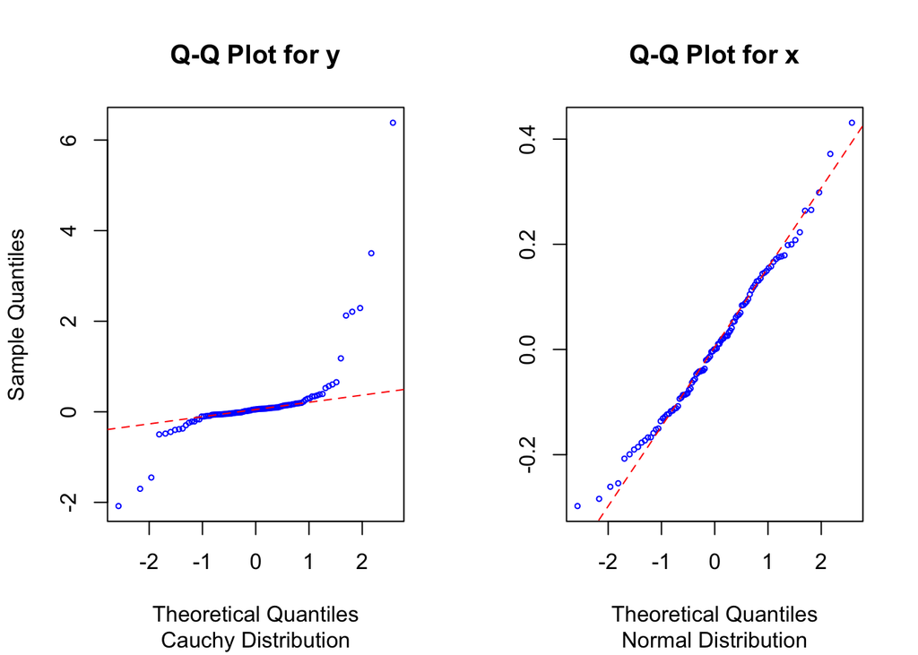

```r
#Configure multi-plot.
par(mfrow = c(1, 2))

#Plot qqnorm and qqline for Cauchy distribution.
qqnorm(y, main = "Q-Q Plot for y", sub = "Cauchy Distribution", cex = 0.5, col = "blue")
qqline(y, col = "red", lty = 2)

#Plot qqnorm and qqline for normal distribution.
qqnorm(x, main = "Q-Q Plot for x", sub = "Normal Distribution", ylab = "", cex = 0.5, col = "blue")
qqline(x, col = "red", lty = 2)
```